# OpenGWASDB ukb-b Dense Store — Chunk-Shape Query Benchmark

1000×1000 vs 1000×128 · genome-wide · 2,514 UK Biobank analyses × ~9.85M variants

Published

August 23, 2026

**ImportantMeasured at `format_version` 0.1, not re-run for the `z` or `eaf` encodings**

Every figure below was measured against stores whose `z` plane is `float16` and which carry no `eaf` at all. Two changes have landed since, both of which move stored size and add a decode step to every read: issue #114 (ADR 0037 §1) made `z` `int16` fixed point with an exact overflow table, and issue #116 (ADR 0037 §2, §4) made `eaf` a per-variant baseline plus an `int8` logit residual and moved `format_version` to 2.0. The sizes and timings here describe neither. They are re-measured against rebuilt stores in #117, before the version that ships the encodings is cut (`CONTRIBUTING.md`, “Benchmarks are measurements, not prose”).

## Overview

Both stores hold the **same** genome-wide ukb-b data — 2,514 UK Biobank GWAS × ~9.85M variants — and differ only in the zarr **chunk shape**. The baseline uses square `1000×1000` chunks; the variant keeps the 1,000-variant rows but narrows the analysis axis to **128**. An identical query selection (the same ALIDs, analysis ids, and region) is run against each store.

The point of interest is the **per-analysis (`bulk`) read**. With a 1,000-analysis-wide chunk, reading one analysis column drags in 999 neighbours per chunk; a 128-wide chunk cuts that waste ~8×. The per-variant (`phewas`) read moves the other way — it now spans more analysis-chunks — so this is a trade, and the table shows both sides.

**Note**

This run uses the **surgical point-lookup read** (issue 052): `lookup` now fetches only the chunks intersecting the requested rows × columns rather than the full analysis width. That removes the earlier `random_lookup` penalty on the narrow chunk (previously ~2.4× slower). It was also measured **concurrently with a reference-completion job reading the 1000×128 store**, so the *absolute* latencies here are ~10–25% higher than an idle-box run; the queries `bulk`, `phewas`, `regional`, and `tophits` are unaffected by issue 052, so their differences from the earlier report are load noise, not real change. The load-robust conclusions are the *ratios within this run*: the `bulk` speedup and the `random_lookup` parity.

| Property | Value |
| --- | --- |
| Analyses (GWAS) | 2,514 |
| Variants (hg38) | 9,847,701 |
| Repetitions (median of) | 7 |
| Baseline chunks | 1000×1000 |
| Variant chunks | 1000×128 |

## Query latency: 1000×1000 vs 1000×128

| Query | 1000×1000 | 1000×128 | Change (128 vs 1000) |
| --- | --- | --- | --- |
| One analysis, all variants (`analysis`) | 38.76 s | 9.96 s | **3.9× faster** |
| One variant × all analyses (`phewas`) | 7.9 ms | 17.9 ms | 2.3× slower |
| All associations in a 1 Mb window (`range_phewas`) | 849.6 ms | 920.5 ms | 1.1× slower |
| Genome-wide significant index read (`top_hits`) | 745.9 ms | 737.4 ms | ≈ same |
| 100 variants × 10 analyses (`lookup`) | 913.8 ms | 935.6 ms | ≈ same |

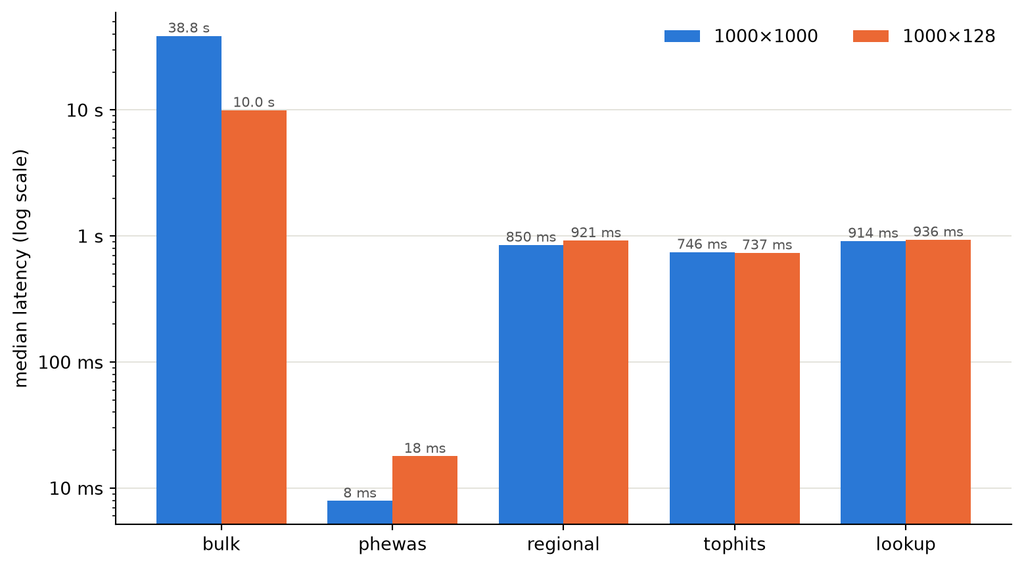

Median query latency by pattern (log scale). Lower is better.

## Storage

| Chunk shape | Store size |
| --- | --- |
| 1000×1000 | 58.0 GB |
| 1000×128 | 54.9 GB |

Chunk shape changes how the same float16 `z`/`se` are grouped on disk, so compressed size shifts only modestly; the point of the narrower analysis chunk is read amplification on per-analysis queries, not storage.

## Takeaway

- **`bulk` (per-analysis) is 3.9× faster** on 1000×128 — the chunk-bound read the narrow analysis chunk targets.
- **`phewas`** is 2.3× slower but stays in the millisecond range: one variant row now spans more analysis-chunks.
- **`random_lookup` is back at parity** (936 ms vs 914 ms on 1000×1000). With the surgical column read (issue 052) a scattered point lookup fetches only the chunks it needs, so the narrow chunk no longer penalises it — before 052 it was ~2.4× slower on 1000×128.
- `regional` and `tophits` are chunk-insensitive.

With surgical point lookups in place, the narrow analysis chunk is close to a free win for a read-mixed workload: a large speedup on per-analysis reads, `phewas` still sub-20 ms, and scattered point lookups back at parity. The square chunk only wins if per-variant PheWAS latency is the single priority.

## Provenance

- Data: `opengwasdb_chunk_comparison_benchmark.json` (from `benchmarks/benchmark_chunk_comparison.py`)
- 1000x1000: `/local-scratch/data/opengwas/opengwasdb/ukb-b.opengwasdb`
- 1000x128: `/local-scratch/data/opengwas/opengwasdb/ukb-b-c128.opengwasdb`